Felodipine ER — full work summary · 42 slides

# Felodipine ER: everything we did, step by step

MBBE drug 2 · PK-Sim PBPK build, release-rate safe space, fed and dissolution gates, PBPK vs PopPK

PK-Sim, Julia BE simulation and Pumas PopPK

1

## The whole project on one page

**Set-up**  
CVs, shipped model checks, particle size dropped

▶

**Refit**  
Weibull refit, disposition check, colonic CYP3A4 = 50%

▶

**Rebuild**  
Rebuild after lost work, population, coarse 13-run cross

▶

**Safe space**  
27-run safe space, fed + dissolution gates, PopPK comparison

▶

**Write-up**  
Summary doc, Word export and this deck

27

PK-Sim population runs (100 subjects each)

4.37–5.23 h

ABE safe T50 at reference shape (×0.91–1.09)

0.79

Model Cmax vs observed (documented bias)

−7% / −15%

PopPK vs PBPK GMR boundaries

Bottom line: the fasted T50 × shape safe space is narrow and a diagonal band. Cmax decides BE. PopPK agrees with PBPK near the reference but diverges off-shape.

Felodipine ER · MBBE drug 2 · full work summary

2

# 1 · Set-up and the model

Why felodipine, what the OSP model is, and the gates we set before any sweep

2

## Why felodipine was chosen as MBBE drug 2

- **Only OSP library compound that meets all three criteria:** free validated PBPK model, BCS II, and a real marketed ER product (Plendil ER)
- **Plendil ER has an FDA product-specific BE guidance**, so the release-rate CQA carries over from metformin
- **Goal:** repeat the 2-D T50 × shape safe space on a second, mechanistically opposite drug
- **Original extra goal:** particle size and solubility CQAs (dropped, step 6)

|  | Metformin XR | Felodipine ER |
| --- | --- | --- |
| BCS class | III (high sol, low perm) | II (low sol, high perm) |
| Rate-limiting step | Permeability, upper-GI window | In-vivo dissolution |
| Clearance | Renal, transporters | Hepatic CYP3A4, high first pass |
| Oral bioavailability | ~50–60% | ~15% |
| Within-subject Cmax CV | ~12% | ~36% |
| Food effect | Modest | Large and erratic |

Felodipine ER · MBBE drug 2 · full work summary

4

3

## The OSP felodipine whole-body PBPK model

- **Source:** github.com/Open-Systems-Pharmacology/Felodipine-Model (Bergmann et al., Pharmaceutics 2022;14:1474)
- **Built as a CYP3A4 victim drug for DDI work**, not for formulation work; validated at OSP's 2-fold level
- **Fitted to 13 studies** (IV, solution, IR, ER) plus an itraconazole DDI
- **Structure:** PK-Sim whole body; GI tract as a chain of segments; drug dissolves, crosses the gut wall, meets gut-wall CYP3A4, then the liver
- **Our risk:** a DDI model can get AUC right but the absorption shape only roughly

| Setting | Value | Origin |
| --- | --- | --- |
| logP | 4.51 | Fitted (OSP) |
| Fraction unbound | 0.0036 | Ushimura 2010 |
| Solubility FaSSIF pH 6.5 | 12 µg/mL | Söderlind 2010 |
| CYP3A4 Michaelis–Menten | Km 2.81 µM; kcat 205 /min | Walsky 2004; kcat fitted |
| Unspecific hepatic CL | 12.8 /min | Fitted |
| Gut-wall P ("P mucosa") | 0.0892 cm/min | Fitted, sim-level override |
| Partitioning / permeability | Rodgers & Rowland / PK-Sim std | PK-Sim methods |
| ER tablet Weibull | T50 286.95 min, lag 18.68, shape 0.764 | Fitted |
| IR tablet Weibull | T50 46.5 min, lag 0, shape 0.888 | Fitted |
| Individual | European male 30 y, CYP3A4 t½ 36 h | OSP |

Felodipine ER · MBBE drug 2 · full work summary

5

4

## Four acceptance gates were set before any CQA sweep

| # | Gate (scope §3.9) | Final status | How it was closed |
| --- | --- | --- | --- |
| 1 | Oral IR / solution profile reproduced | Partly | Solution AUC 1.03; IR AUC overpredicted 1.58× (one dataset) |
| 2 | ER fasted Cmax and AUC within 1.25-fold | Accepted with bias | AUC 1.04; Cmax 0.79, disposition-driven, documented |
| 3 | Fed arm shows direction and size of food effect | Failed → sensitivity | Model fed/fasted Cmax 0.96 vs 1.6–2.8 observed |
| 4 | Reference Weibull traceable to real dissolution | Closed, approximate | Abrahamsson 1994 tablets A/B/C within 1.25-fold |

Results from the sweep are therefore reported as a fasted claim with a documented Cmax bias and fed as a within-subject-variability sensitivity.

Felodipine ER · MBBE drug 2 · full work summary

6

# 2 · First model checks

Variability inputs, the shipped model against data, and dropping the particle-size CQA

5

## Within-subject CVs sourced from the MHRA public assessment report

| Study (Delofine XL vs Plendil) | Cmax CV | AUC CV |
| --- | --- | --- |
| 10 mg fasting, 2×2 | 35.7% | 24.3% (AUC0–∞) |
| 10 mg fed, 2×2 | 36.5% | 22.2% (AUC0–∞) |
| 10 mg steady state, replicate | 21.6% | 14.9% (AUCτ) |
| 2.5 mg fasting, 4-period replicate | 30.8% (CVwR ≈ 34%) | 28.9% |

Source: UK MHRA PAR, Felodipine/Delofine XL (PL 20117/0397-0399); healthy males.

n = 54

ABE 2×2 fasted (Cmax CV 35.7%, GMR 0.95, 80% power)

n = 56

Fed design (Cmax CV 36.5%)

n = 24

RSABE / ABEL full replicate, CVwR 34%

Decision D1: ABE 2-way crossover is primary (FDA guidance); RSABE on Cmax is a sensitivity. Cmax is ~3× metformin's 12% CV; n = 48 is not reused.

Felodipine ER · MBBE drug 2 · full work summary

8

6

## The shipped model underpredicts ER Cmax by about 22%

| ER 10 mg study (training) | Cmax p/o | AUC p/o |
| --- | --- | --- |
| Edgar 1987 (n=12, 12 h) | 0.73 | 0.87 |
| Bailey 1996 (n=12, 24 h) | 0.63 | 1.02 |
| Gelal 2005 (n=10, serum) | 1.05 | 1.21 |
| Bailey 2003 (n=8, 8 h) | 0.76 | 1.04 |
| **Geometric mean** | **0.78** | **1.03** |

- **AUC passes our 1.25-fold criterion; Cmax fails.** OSP's "validated" means within 2-fold, which is looser
- **IR check (Edgar 1987, n=12):** Cmax 1.32×, AUC0–12 1.58× — overprediction from 2 h on, so likely disposition, not formulation
- **Snapshot formulations confirmed:** ER T50 286.95 min / lag 18.68 / shape 0.764; IR 46.5 / 0 / 0.888; solubility 12 µg/mL

Felodipine ER · MBBE drug 2 · full work summary

9

7

## No particle radius fits the IR data better than the shipped Weibull

| IR formulation | Cmax p/o | tmax (obs 1 h) | AUC0–12 p/o | Peaks | log-RMSE |
| --- | --- | --- | --- | --- | --- |
| **Weibull (shipped)** | 1.32 | 1.2 h | 1.58 | 1 | **0.58** |
| 0.5 µm | 2.69 | 0.65 h | 1.61 | 1 | 0.96 |
| 1 µm | 2.29 | 0.85 h | 1.70 | 1 | 0.85 |
| 2 µm | 1.68 | 1.05 h | 2.00 | 1 | 0.81 |
| 3 µm | 1.31 | 1.2 h | 2.24 | 2 | 0.89 |
| 5 µm | 1.23 | 5.75 h | 2.50 | 2 | 1.02 |
| 10 µm | 1.11 | 7.25 h | 2.42 | 1, late | 1.12 |
| 25 µm | 0.74 | 9.5 h | 1.57 | 1, late | 1.19 |
| 50 µm | 0.47 | 11.5 h | 0.96 | 1, late | 1.42 |

- **Why a double peak:** to lower Cmax, dissolution must slow; undissolved drug reaches the colon, dissolves late and escapes gut CYP3A4, so AUC rises
- **Structural trade-off:** no radius avoids both "Cmax too high" and "second peak"
- **PK-Sim 12.2 limit:** Parameter Identification cannot fit particle radius; the "radius" entries it offers are physiology — never fit those

Felodipine ER · MBBE drug 2 · full work summary

10

8

## Particle size and solubility were dropped as felodipine CQAs

- **No public Plendil API particle size** — the patent (US 4,803,081) says only "micronized"
- **Plendil ER is surfactant-solubilised:** polyoxyl 40 hydrogenated castor oil in an HPMC gel matrix, so drug leaves in solution
- **Rat data run opposite to the model:** smaller particles gave higher bioavailability (25 µm 173% vs 200 µm 100%)

| # | Decision | Why |
| --- | --- | --- |
| D1 | MHRA CVs; ABE primary, RSABE sensitivity | Only public originator ISCV source |
| D2 | No individual-subject exports yet | Wait for locked reference and population |
| D3 | Drop particle size and solubility | Structural trade-off; same lever (S/r); not a real-product CQA |
| D4 | Keep T50 × shape, high variability, food | What felodipine does best, with an FDA guidance |
| D5 | Particle-radius CQA needs another BCS II drug | Not yet screened |
| D6 | Next: refit the ER Weibull | ER Cmax 0.78; Cmax decides BE |

Felodipine ER · MBBE drug 2 · full work summary

11

9

## Early export problems led to a checklist used for every export

What went wrong

- The rad10 export was really the reference sim
- rad5 duplicated rad25
- A re-copied download "(1)" was taken for new results
- Two batches ran to 24 h instead of 96 h

Checklist from then on

- Configure → Administration: formulation matches the sim name
- Output intervals end at 96 h and the chart reaches 96
- Unique filename with radius/T50 and "96h"
- All observed datasets on the chart; I check checksums, end time and parameter-vs-shape

Felodipine ER · MBBE drug 2 · full work summary

12

10

## Data audit: 34 datasets, no grapefruit arms, a train/test split

| Group | Datasets in the OSP snapshot |
| --- | --- |
| ER 10 mg train (4) | Edgar 1987, Bailey 1996, Bailey 2003, Gelal 2005 (serum) |
| ER 10 mg test (6) | Dresser 2002/2017, Bailey 1998/2000, Lundahl 1997, Madsen 1996 |
| ER, other | Multiple dose: Aberg 1997, Bailey 1995, Lundahl 1998, Blychert 1990; 5/2.5 mg: Goosen 2004, Dresser 2000, Jalava 1997; Guo 2007 (unattached) |
| IR | Edgar 1987, Smith 1987, Edgar 1992, Bailey 1993, Bratel 1989 (fed), Blychert 1990 |
| Solution / IV | Edgar 1987, Blychert 1990 / Lundahl 1997 |

Felodipine ER · MBBE drug 2 · full work summary

13

# 3 · Refit and reference lock

Weibull refit, disposition diagnosis, colonic CYP3A4, and the locked reference

11

## Against all 10 fasted ER studies the profile is too flat

| Set | Study | Cmax p/o | AUC0–tlast p/o |
| --- | --- | --- | --- |
| train | Edgar 1987 | 0.73 | 0.87 |
| train | Bailey 1996 | 0.63 | 1.07 |
| train | Bailey 2003 | 0.76 | 1.04 |
| train | Gelal 2005 | 1.05 | 1.23 |
| test | Lundahl 1997 | 0.83 | 1.16 |
| test | Dresser 2017 | 0.76 | 0.90 |
| test | Dresser 2002 | 1.00 | 1.32 |
| test | Bailey 2000 | 0.89 | 1.23 |
| test | Bailey 1998 | 0.49 | 0.81 |
| test | Madsen 1996 | 0.94 | 1.43 |
| **GM** | **train / test / all** | **0.78 / 0.80 / 0.79** | **1.04 / 1.12 / 1.09** |

[figure not shown]

- **Too much drug early, too little at the peak, too much in the tail** — the signature of Weibull shape < 1
- Predicted Cmax 4.60 nM at 3.0 h vs observed 4.4–9.4 nM at 2.5–5 h

Felodipine ER · MBBE drug 2 · full work summary

15

12

## The Weibull refit worked as a fit but did not fix Cmax

T50 296 ± 52 min

95% CI ≈ 244–348; shipped 287 inside

Shape 0.89 ± 0.08

≈ 0.81–0.97; shipped 0.764 outside

r = −0.53

T50–shape correlation: not confounded

PI on the 4 training studies, log scaling, Levenberg–Marquardt, 10 random starts, lag fixed; all starts reached total error 0.95.

|  | Cmax GM | AUC GM | 0–2 h | 2–6 h | 6–12 h | 12–24 h |
| --- | --- | --- | --- | --- | --- | --- |
| train, shipped | 0.78 | 1.04 | 1.31 | 0.86 | 1.19 | 1.83 |
| train, refit | 0.77 | 1.07 | 1.02 | 0.87 | 1.31 | 1.82 |
| test, shipped | 0.80 | 1.12 | 1.18 | 0.92 | 1.24 | 4.60 |
| test, refit | 0.79 | 1.14 | 0.91 | 0.94 | 1.36 | 4.74 |

The refit fixes the early phase, slightly worsens the tail and leaves Cmax at 0.77–0.79. Observed profiles peak higher and fall faster at the same AUC — a release change cannot do that, so the cause is disposition.

Felodipine ER · MBBE drug 2 · full work summary

16

13

## IV and solution: disposition is off, oral AUC right by cancellation

| IV 1.5 mg, Lundahl 1997 | Model | Observed | Ratio |
| --- | --- | --- | --- |
| AUC∞ (µmol·min/L) | 3.63 | 4.59 | 0.79 |
| Cmax end of infusion (nM) | 22.3 | 30.0 | 0.74 |
| CL (mL/min/kg) | 14.7 | 11.6 | **1.27** |
| Vss (mL/kg) | 4985 | 3090 | **1.61** |
| t½ (h) | 8.1 | 5.7 | **1.42** |

Oral solution 10 mg (Edgar 1987): AUC∞ 1.03, Cmax 1.24. Implied F: model 0.20 vs observed 0.15 (literature ~15%).

- **CL too high (×1.27) and F too high (×1.3) cancel** in oral AUC
- **Excess Vss and t½ flatten slow-input profiles:** low peak, high tail — most of the ER Cmax 0.79
- **ER tail excess (1.8–4.7) is bigger than IV or solution tails**, so a second, ER-specific cause is likely: colonic absorption without gut first pass

Options considered

- A — accept the documented Cmax bias, use only T/R ratios
- B — recalibrate disposition (risks OSP's DDI validation)
- **C — colon-specific lever, then T50 refit (chosen)**

Felodipine ER · MBBE drug 2 · full work summary

17

14

## Colonic CYP3A4 at 50% of the small intestine fixes the tail, not Cmax

| Colonic CYP3A4 | F | Cmax GM | AUC GM | 12–24 h train / test |
| --- | --- | --- | --- | --- |
| 0 (shipped) | ~0.20 | 0.789 | 1.089 | 1.83 / 4.60 |
| 10% of SI (0.0073) | 0.200 | 0.789 | 1.068 | 1.49 / 3.93 |
| 25% of SI (0.018) | 0.186 | 0.788 | 1.054 | 1.27 / 3.48 |
| **50% of SI (0.036)** | **0.176** | **0.787** | **1.042** | **1.12 / 3.14** |

Shipped model: CYP3A4 in liver and small-intestine segments (0.073) but none in the large intestine, while AADAC and P-gp do have colon entries.

Reference locked (decision)

- Shipped ER Weibull: T50 286.95 min, lag 18.68 min, shape 0.764
- Colonic CYP3A4 = 0.036 in all large-intestine segments
- Second refit (step 5c) skipped
- Cmax bias ≈ 0.79 documented as disposition-driven

Logged as a deviation from scope §3.9: gates #2–#4 not yet met, so sweep results were provisional until they closed.

Felodipine ER · MBBE drug 2 · full work summary

18

15

## Rebuild did not match, and the work was not saved

|  | Colon-50 clone | New individual |
| --- | --- | --- |
| Cmax | 4.59 nM @ 3.0 h | 4.72 nM @ 2.75 h |
| F | 0.176 | 0.159 |
| Fraction absorbed | 0.981 | 0.959 |
| CL (mL/min/kg) | 14.27 | 14.35 |
| 0–2 h p/o | 1.31 | 1.47 |

- **Stage 6a:** new profile `CYP3A4 36 h colon50` and individual `European_colonCYP3A4_50`, sim switched via Configure — check failed
- **Suspected cause:** OSP stores 27 simulation-level overrides that Configure may drop
- **Later finding:** none of this PK-Sim work was saved (clones, profile, individual); only the xlsx exports survived
- **Rule since:** always end a PK-Sim stage with File → Save

Felodipine ER · MBBE drug 2 · full work summary

19

# 4 · Rebuild and population

The override hunt, the virtual population, BE code, and the coarse cross

16

## Configure drops OSP's simulation overrides; Clone keeps them

| Step | What we found | Result |
| --- | --- | --- |
| 9.8 | Original individual checked: LI CYP3A4 = 0, SI 0.07 | Clean |
| 9.9 | First snapshot sent was the older particle-size project | Wrong file |
| 9.10 | 22 P(int↔cell) = OSP fitted "P mucosa" 0.0892 cm/min | Not cosmetic |
| 9.11 | Rebuild without re-entry = earlier failure to the digit | Overrides absent |
| 9.12 | Screenshots: P mucosa survived Configure (User Defined) | Refuted for 22 |
| 9.13 | Snapshot diff: only Tablet time delay factor missing | Cause found |
| 9.14 | v2 with delay factor 0.0695415108 re-entered | Match to 3.3e-5 |

The 27 OSP overrides (reference/ER_tablet_10mg_sim_overrides.csv)

- 22 × gut-wall P (interstitial↔intracellular) = 0.0891674187 cm/min
- Tablet time delay factor = 0.0695415108
- Water volume 3.5 mL/kg; Undefined Liver × 3

Configure → individual drops the delay factor. Configure → population also drops the 22 P mucosa values. Clone keeps everything.

Reference restored in Felodipine_ER_colon50.pksim5: Cmax 4.588 nM @ 3.0 h, AUC0–96 4.383 µM·min, F 0.1765, all-10 Cmax 0.787 / AUC 1.042.

Felodipine ER · MBBE drug 2 · full work summary

21

17

## One 100-subject population, reused for every formulation

| Pop_felo_100 | Value |
| --- | --- |
| Base individual | European_colonCYP3A4_50 |
| Size / sex | 100 subjects, 50 F / 50 M |
| Age | 18.2–54.7 y (requested 18–55) |
| Weight / BMI | 41–98 kg / 19–30 kg/m² |
| Dose | 10 mg ER, single dose, fasted |
| Run length | 0–96 h |
| Overrides | 23 re-entered by hand in Pop_ref |

100, not 24: trials need ~54 subjects and resampling from 24 physiologies duplicates heavily. Every sweep run is a clone of Pop_ref, so test and reference are paired.

| Pop_ref | Individual | Median | GM | Range | BSV CV |
| --- | --- | --- | --- | --- | --- |
| Cmax (nM) | 4.59 | 5.26 | 5.16 | 1.65–10.98 | 35% |
| tmax (h) | 3.0 | 2.75 | 2.71 | 1.9–3.75 | 15% |
| AUC0–96 (µM·min) | 4.38 | 5.18 | 5.16 | 1.39–12.98 | 39% |

- **~1.15× above the individual, uniformly over time** — fits the demographics (half lighter women, fixed dose); not the missing-delay signature (that is early up, late down)
- **Accepted as a correct build**

Felodipine ER · MBBE drug 2 · full work summary

22

18

## be_utils.jl was refactored so one BE engine serves both drugs

- **Metformin API unchanged:** all 5 metformin output CSVs byte-identical before and after
- **Added:** DRUG_CONFIG, wsv_cv(drug, arm, endpoint), parse_formulation (T50, shape), drug-aware loader (venous blood rows only, errors on duplicates)
- **Added:** power_abe_2x2 / sample_size_abe_2x2, full-replicate FDA RSABE (sWR ≥ 0.294) and EMA ABEL (cap at CVwR 50%)
- **21 tests pass** (programs/julia/test_be_utils.jl)

| Test | Result |
| --- | --- |
| n at CV 0.20 / 0.25 / 0.30 | 20 / 28 / 40 (PowerTOST) |
| Felodipine fasted Cmax CV 0.357 | n = 54 |
| Felodipine fed Cmax CV 0.365 | n = 56 |
| Loader reproduces T50 2.39 h GMR | 1.488 |
| RSABE self-comparison, n = 24 | 97% pass |
| True GMR 1.25: ABE / RSABE pass | 4.6% / 20.8% |

The 20.8% at GMR 1.25 is the known RSABE type I inflation — worth reporting.

Felodipine ER · MBBE drug 2 · full work summary

23

19

## Coarse cross (13 runs): Cmax moves with T50 and is U-shaped in shape

[figure not shown]

Joint ABE power ≥ 0.80 (n = 54) only inside T50 ×0.85–1.2; shape tolerates 0.764→1.0 but not 0.6 or 1.2. AUC passes almost everywhere. Every T50/shape was verified from the lumen fraction dissolved.

Felodipine ER · MBBE drug 2 · full work summary

24

# 5 · The safe space

2-D fill, edge runs, and the 27-formulation result

20

## 27 formulations were simulated in three rounds

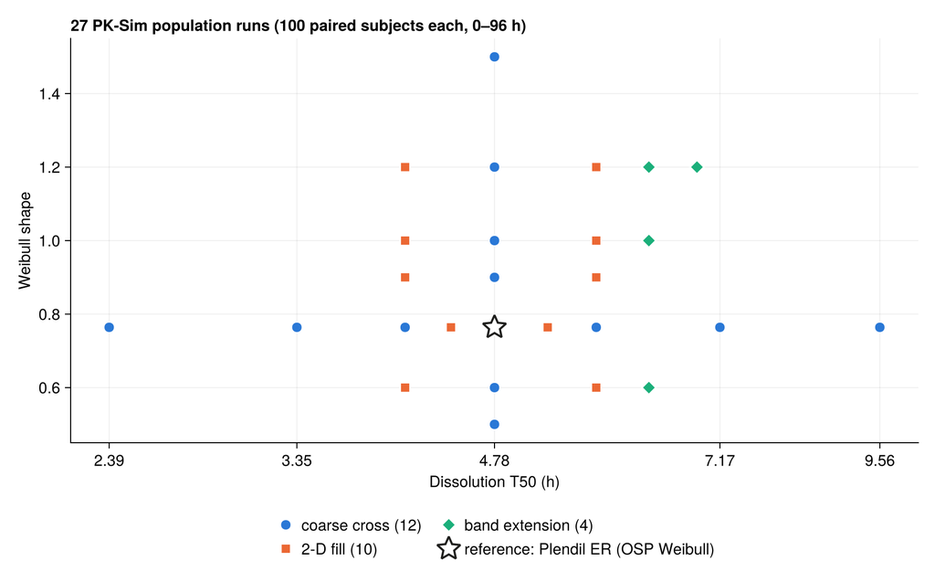

- **Coarse cross (12 + ref):** T50 axis and shape axis
- **2-D fill (10):** T50 4.07 and 5.74 h × shapes 0.6–1.2, plus 4.42 and 5.26 h at 0.764
- **Band extension (4):** 6.31 h × 0.6/1.0/1.2 and 6.88 h × 1.2
- **Upload checks caught:** a missing PK-Analyses file (re-exported) and "5.7 h" files that were really 344 min (renamed 5.74 h)

Felodipine ER · MBBE drug 2 · full work summary

26

21

## Matrix sweep results, runs 1–14: relative BA and power

| T50 h (min) | Shape | BA Cmax GMR | BA AUC0–t GMR | ABE Cmax | ABE AUC | ABE joint | RSABE | ABEL |
| --- | --- | --- | --- | --- | --- | --- | --- | --- |
| 2.39 (143) | 0.764 | 1.488 | 1.040 | 0.00 | 0.99 | 0.00 | 0.00 | 0.00 |
| 3.35 (201) | 0.764 | 1.229 | 1.026 | 0.10 | 1.00 | 0.08 | 0.29 | 0.20 |
| 4.07 (244) | 0.6 | 1.189 | 0.970 | 0.19 | 0.99 | 0.18 | 0.45 | 0.33 |
| 4.07 (244) | 0.764 | 1.099 | 1.013 | 0.62 | 1.00 | 0.59 | 0.81 | 0.73 |
| 4.07 (244) | 0.9 | 1.116 | 1.032 | 0.52 | 0.99 | 0.49 | 0.75 | 0.66 |
| 4.07 (244) | 1.0 | 1.149 | 1.040 | 0.35 | 0.99 | 0.32 | 0.62 | 0.52 |
| 4.07 (244) | 1.2 | 1.243 | 1.050 | 0.07 | 0.98 | 0.06 | 0.25 | 0.14 |
| 4.42 (265) | 0.764 | 1.047 | 1.007 | 0.84 | 1.00 | 0.83 | 0.94 | 0.91 |
| 4.78 (287) | 0.5 | 1.229 | 0.904 | 0.10 | 0.80 | 0.06 | 0.29 | 0.19 |
| 4.78 (287) | 0.6 | 1.094 | 0.951 | 0.64 | 0.97 | 0.61 | 0.82 | 0.74 |
| **4.78 (287) ref** | **0.764** | **1.000** | **1.000** | 0.90 | 1.00 | **0.90** | 0.97 | 0.95 |
| 4.78 (287) | 0.9 | 1.010 | 1.022 | 0.89 | 1.00 | 0.89 | 0.97 | 0.94 |
| 4.78 (287) | 1.0 | 1.037 | 1.032 | 0.86 | 0.99 | 0.85 | 0.95 | 0.92 |
| 4.78 (287) | 1.2 | 1.119 | 1.045 | 0.50 | 0.98 | 0.46 | 0.74 | 0.65 |

BA = paired test/reference geometric-mean ratio in 100 subjects. Power = share of 1000 simulated trials passing: ABE 2×2 n = 54 (CV Cmax 35.7%, AUC0–t 25.3%); RSABE / ABEL on Cmax, n = 24, CVwR 34%. Shaded: joint power ≥ 0.80.

Felodipine ER · MBBE drug 2 · full work summary

27

22

## Matrix sweep results, runs 15–27: relative BA and power

| T50 h (min) | Shape | BA Cmax GMR | BA AUC0–t GMR | ABE Cmax | ABE AUC | ABE joint | RSABE | ABEL |
| --- | --- | --- | --- | --- | --- | --- | --- | --- |
| 4.78 (287) | 1.5 | 1.269 | 1.055 | 0.03 | 0.97 | 0.03 | 0.17 | 0.10 |
| 5.26 (316) | 0.764 | 0.946 | 0.991 | 0.79 | 1.00 | 0.79 | 0.91 | 0.87 |
| 5.74 (344) | 0.6 | 0.996 | 0.927 | 0.90 | 0.91 | 0.82 | 0.97 | 0.94 |
| 5.74 (344) | 0.764 | 0.898 | 0.981 | 0.52 | 1.00 | 0.54 | 0.76 | 0.67 |
| 5.74 (344) | 0.9 | 0.901 | 1.008 | 0.53 | 1.00 | 0.55 | 0.76 | 0.68 |
| 5.74 (344) | 1.0 | 0.922 | 1.020 | 0.67 | 1.00 | 0.67 | 0.85 | 0.79 |
| 5.74 (344) | 1.2 | 0.990 | 1.036 | 0.90 | 0.99 | 0.88 | 0.97 | 0.94 |
| 6.31 (379) | 0.6 | 0.947 | 0.913 | 0.79 | 0.85 | 0.69 | 0.92 | 0.88 |
| 6.31 (379) | 1.0 | 0.865 | 1.012 | 0.30 | 1.00 | 0.31 | 0.58 | 0.44 |
| 6.31 (379) | 1.2 | 0.927 | 1.030 | 0.70 | 0.99 | 0.70 | 0.88 | 0.81 |
| 6.88 (413) | 1.2 | 0.873 | 1.023 | 0.35 | 1.00 | 0.36 | 0.62 | 0.49 |
| 7.17 (430) | 0.764 | 0.786 | 0.952 | 0.03 | 0.97 | 0.03 | 0.14 | 0.09 |
| 9.56 (574) | 0.764 | 0.659 | 0.904 | 0.00 | 0.81 | 0.00 | 0.00 | 0.00 |

AUC0–t power is ≥ 0.85 everywhere except 4.78 h / shape 0.5 and 9.56 h (0.80–0.81): Cmax is the binding metric. Scripts felo_02_be_sweep.jl → output_sweep_2d/.

Felodipine ER · MBBE drug 2 · full work summary

28

23

## The safe space is a diagonal band, not a box

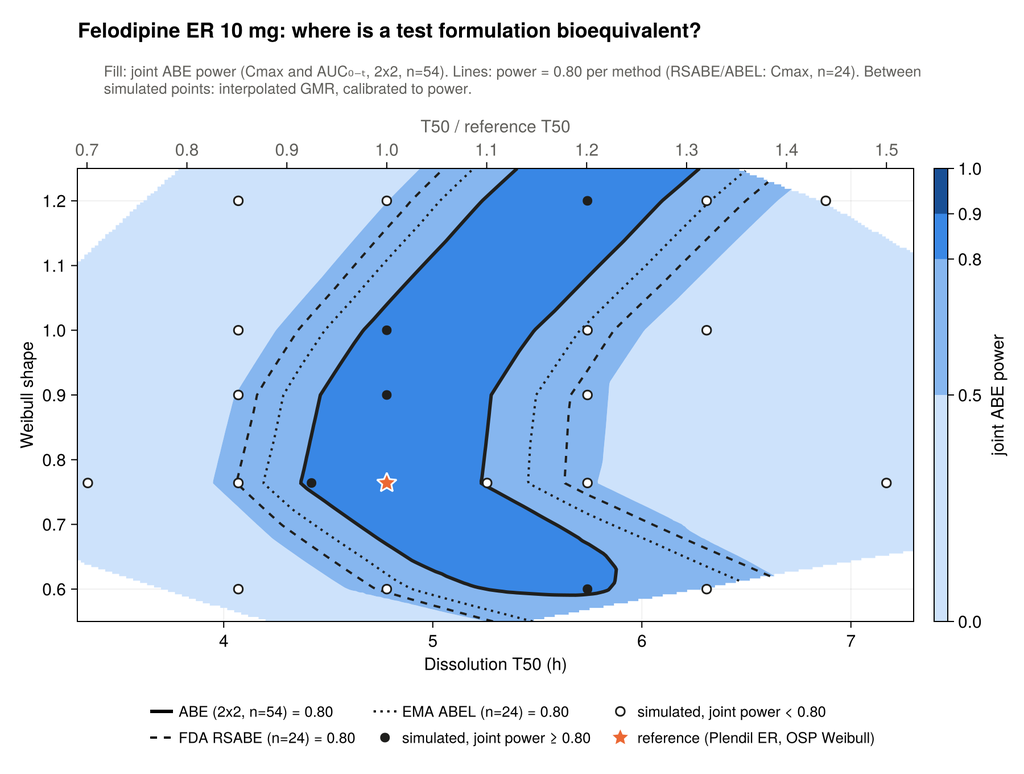

| Shape | ABE n=54 | RSABE n=24 | ABEL n=24 |
| --- | --- | --- | --- |
| 0.6 | 5.25–5.84 | 4.73–≥6.31 | 4.90–≥6.31 |
| **0.764** | **4.37–5.23** | 4.07–5.63 | 4.19–5.46 |
| 0.9 | 4.47–5.28 | 4.16–5.66 | 4.29–5.49 |
| 1.0 | 4.67–5.49 | 4.36–5.87 | 4.49–5.70 |
| 1.2 | 5.24–6.10 | 4.90–6.50 | 5.04–6.33 |

- T50 range (h) with joint power ≥ 0.80
- **At fixed T50, Cmax is lowest near shape 0.8**, so a slower T50 is offset by moving shape either way
- **Method:** log GMR interpolated on a Delaunay mesh, isotonic calibration to power (within 0.036 of all 27 runs)

Felodipine ER · MBBE drug 2 · full work summary

29

# 6 · Fed and dissolution gates

Gate #3 food effect and gate #4 in-vitro link

24

## Fed literature sets the target: Cmax up 1.6–2.8×, AUC unchanged

| Source | Fed / fasted Cmax | Note |
| --- | --- | --- |
| Sandoz CA monograph (Plendil arm) | ×2.77 | AUC∞ ×1.09; tmax 4.5 h both |
| US Plendil label | ≈ +60% | AUC unchanged |
| Weitschies 2005 (n=6) | ×1.63 | Bursts from proximal stomach |
| Apotex CA monograph | ×3.54 | Different subjects; not used |

Profiles: Kim 2014 PLoS One figs (digitisable, < 8 h); Abrahamsson 1993 Pharm Res (paywalled). Registered fed BE trials (NCT02311530, NCT01630902) posted no results. Full write-up: reference/fed-arm-literature.md.

1.6–2.8

Target Cmax fed/fasted

1.0–1.1

Target AUC fed/fasted

0.81 / 0.89

Fasted model vs Sandoz Plendil: Cmax / AUC∞

Felodipine ER · MBBE drug 2 · full work summary

31

25

## The model cannot produce the food effect, so fed became a sensitivity

0.96

Cmax fed/fasted (target 1.6–2.8)

1.01

AUC∞ fed/fasted (target ≈ 1.0–1.1)

2.75 → 5.0 h

Median tmax (observed unchanged at 4.5 h)

Unchanged

Safe space with fed CV 36.5%, n = 56

Pop_fed_ref = clone of Pop_ref + high-fat breakfast event at t = 0; Configure kept the P mucosa values this time. The meal template used was not recorded.

- **Why it fails:** the Weibull release is a fixed function of time, so the meal only slows gastric emptying — Cmax falls slightly
- **What really happens:** the tablet sits in the proximal stomach, released drug empties in bursts and more escapes gut-wall extraction (Weitschies 2005, Bergstrand 2009)
- **PK-Sim's meal event has neither mechanism**
- **Decision (option A):** claim the fasted safe space only; fed = within-subject-variability sensitivity (scope §10)

Felodipine ER · MBBE drug 2 · full work summary

32

26

## Dissolution link: the in-vivo Weibull fails USP Test 1 at 10 h

| USP Felodipine ER Test 1 | 2 h | 6 h | 10 h |
| --- | --- | --- | --- |
| Limits (App. 2, 50 rpm, pH 6.5 + 1% SLS) | 10–30% | 42–68% | ≥ 75% |
| Reference in-vivo Weibull, read as in vitro | 26.9% | 54.7% | **69.6% — fails** |

- **Real Plendil passes USP**, so in vitro and in vivo differ in shape, not just timescale; a 1:1 map is wrong
- **Abrahamsson 1994 (Pharm Res):** tablets A/B/C on the same HPMC platform, n = 16, IVIVC r² 0.94–0.97
- **Its SLS 50 rpm row = USP Test 1:** reference MDT 9.4 h sits inside the USP-implied 4.5–12.9 h — consistent, but a weak constraint
- Vetchy 2007 (no basket) cannot be chained to the correlation

Proposal that followed

- Fit Weibulls to the paper's in-vivo dissolution for tablets A, B and C
- Run each as a clone of Pop_ref in PK-Sim
- Compare Cmax levels and Cmax ratios with the observed mean curves
- Use it as an external check of the model's Cmax sensitivity to release rate

Felodipine ER · MBBE drug 2 · full work summary

33

27

## Tablets A/B/C: three real formulations reproduced within 1.25-fold

[figure not shown]

Model / observed: A 1.20, B 0.96, C 0.91.

| Ratio | Model | Observed | Difference |
| --- | --- | --- | --- |
| Cmax B/C | 2.31 | 2.17 | +6% |
| Cmax A/B | 2.36 | 1.90 | +24% |
| AUC C/B | 0.80 | 0.93 | slow tablet under-absorbed |

- **Slow side right (+6%); fast side overstated ~25%**, so the band's short-T50 edge is conservative
- **Gate #4 closed** as "consistent, approximate, with a documented fast-side conservatism"
- **Caveats:** Weibulls from deconvolution, digitised by eye; observed are young Swedish men, n = 16

Felodipine ER · MBBE drug 2 · full work summary

34

# 7 · PBPK vs PopPK

Same pipeline as metformin: fit PopPK to simulated studies and compare BE decisions

28

## PopPK set-up: per-arm fits on rich simulated studies

1

**01 dataset**  
PBPK subjects → 18 samples (0.5–96 h), 15% proportional error; 27 arms × 100

2

**02 fit**  
Per-arm FOCE, both basin starts, keep higher LL; NCA on 0.05 h IPRED grid

3

**03 collect**  
Copy to poppk/output_rich/ in PK-Sim format so felo_02/03 run unchanged

4

**04–06**  
Compare + type I (20k trials), diagnostics, design figure

- **2-cmt + Weibull was unidentifiable** (Q or Vp hit bounds), so 1-cmt + Weibull, lag 0.3113 h, IIV on alpha, CL, Vc
- **Two likelihood basins:** release-limited (flip-flop) and disposition-limited (Vc ≈ 4000 L, t½ ≈ 9 h)
- **23 arms disposition-limited, 4 release-limited;** σ 0.16–0.24 vs true 0.15
- **PopPK release parameters do not map onto PK-Sim T50**, unlike metformin
- Run: julia -J pumas.so --project=julia-env

Felodipine ER · MBBE drug 2 · full work summary

36

29

## PopPK agrees near the reference but the band diverges off-shape

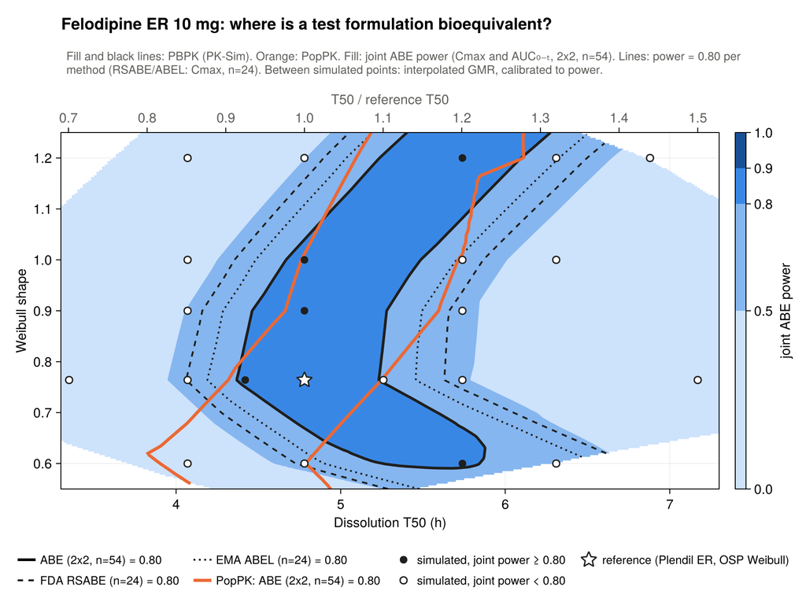

| Shape | PopPK (h) | PBPK (h) |
| --- | --- | --- |
| 0.6 | 3.91–4.79 | 5.25–5.84 (no overlap) |
| 0.764 | 4.32–5.25 | 4.37–5.23 |
| 0.9 | 4.67–5.60 | 4.47–5.28 |
| 1.0 | 4.77–5.71 | 4.67–5.49 |
| 1.2 | 5.10–6.11 | 5.24–6.10 |

- **Per subject:** AUC0–t within ±3% in every arm; Cmax 0.87 (shape 0.5) to 1.135; ref 1.089
- **Bias does not cancel in T/R:** shape 0.5 Cmax GMR 1.229 PBPK vs 0.984 PopPK
- **1-D T50 axis agrees within 0.08 h** (4.38–5.21 vs 4.31–5.21)

Felodipine ER · MBBE drug 2 · full work summary

37

30

## Type I error: both are calibrated, but PopPK moves the GMR boundaries

| T50 axis | PBPK | PopPK | Shift | True GMR there / truth passes |
| --- | --- | --- | --- | --- |
| Fast side (GMR 1.25) | 3.25 h | 2.78 h | −15% | 1.37 / 0.2% (n=54), 0.5% (n=24) |
| Slow side (GMR 0.80) | 6.96 h | 6.45 h | −7% | 0.84 / 15.8% (n=54), 8.2% (n=24) |

- **Calibrated at their own boundary:** 4.5–5.1% for Cmax and joint at n = 54; TOST control 4.96%
- **Fast side anti-conservative, slow side conservative**
- **Shape axis:** PBPK reaches GMR 1.25 at 1.46; PopPK never does
- **RSABE / ABEL at the ABE boundary (n=24):** 20–22% / 13–14% for both

−1.1% / −6.8%

Metformin PopPK vs PBPK boundaries

−7% / −15%

Felodipine PopPK vs PBPK boundaries

PopPK–PBPK decision agreement needs structural adequacy; for felodipine it fails off-reference even with rich sampling.

Discussion deck (18 slides): docs/Discussion-deck_PBPK-vs-PopPK_offline.html · scripts felo_04 (compare, type I), felo_05 (diagnostics), felo_06 (design).

Felodipine ER · MBBE drug 2 · full work summary

38

# 8 · Wrap-up

Lessons, where everything lives, and what is still open

31

## PK-Sim gotchas we learned the hard way

Model handling

- Configure drops OSP sim-level overrides; Clone keeps them — re-enter from the overrides CSV
- Overrides show under Parameters → User Defined (+ Find box); neighbourhoods in the detailed tree
- Do not "update from building block" on colon clones — it resets colonic CYP3A4 to 0
- PI cannot fit particle radius; never fit the physiology "radius" entries

Working remotely

- Always File → Save at the end of each stage (a full day of work was lost once)
- Verify every export: checksums, 96 h end, observed data, parameter vs curve
- Ask for a screenshot instead of guessing a UI label
- Ask for a project snapshot JSON — and check it is the current project

Felodipine ER · MBBE drug 2 · full work summary

40

32

## Where everything is saved

| Item | Location (Felodipine-BCSII/ unless stated) |
| --- | --- |
| PK-Sim project (local installation) | Felodipine_ER_colon50.pksim5 (baseline Felodipine_original.pksim5 untouched) |
| Project notes, all decisions | project notes (not included) · scope: planning notes (not included) |
| PK-Sim exports | pksim-particle-size-pk/ · pksim-releaserate-cqa-er/ (matrix_Sweep_td50_shape/, 16Oct2026sims/, fed-sims/, tablets-1994/) |
| Sweep results | output_sweep_coarse/ · output_sweep_2d/ · output_sweep_2d_fedcv/ · output_tablets1994/ |
| PopPK | poppk/ (src, scripts, output_rich/, output_sweep_2d_poppk/) · runs in poppk-fits/ |
| Analysis scripts | scripts/felo_02 … felo_06 (run from programs, julia --project=.) · scripts/score.py, xl.py |
| References | reference/: OSP snapshot JSON, overrides CSV, fed + dissolution literature, digitised/ |
| Decks | Explainer v14: docs/Explainer-deck_PKSim-model-fix_offline.html · Discussion: docs/Discussion-deck_PBPK-vs-PopPK_offline.html |
| Summary doc | docs/Felodipine-ER-PKSim-Work-Summary.docx · Word copy: Felodipine-ER-PKSim-Work-Summary.docx |
| This deck | slides/full-summary/Felodipine-ER-Full-Work-Summary.pptx and .html · generator scripts/build_full_deck.js |

Felodipine ER · MBBE drug 2 · full work summary

41

33

## PK-Sim work is finished; these decisions are open

Proposed next steps

- NCA on the sampled data (model-free comparator)
- Joint PopPK model across arms (T50 and shape covariates)
- Richer absorption model (transit or two-phase)
- Sparse sampling (6 samples)
- Felodipine write-up

Open questions and loose ends

- Report the PopPK divergence as is, or improve PopPK first?
- Literature: colon vs SI CYP3A4 ratio (supports 50%); Blychert 1990 market vs trial
- Record the meal template used in Pop_fed_ref
- Class B (particle size) CQA needs a different BCS II drug — not screened
- Refresh the MBBE archive with the felodipine work when asked

Felodipine ER · MBBE drug 2 · full work summary

42